# MONEYMOVIE: Em busca da produção perfeita

## **Introdução: Os primeiros desafios**

Temos o desafio de encontrar o filme ideal para a produção dos diretores Athos Damiani e Fernando Correa. Para responder ao desafio, buscaremos um conceito de produção que seja, ao mesmo tempo, rentável e sucesso de críticas. Para atender a isso, resolvemos nos apropriar de um conceito utilizado (curiosamente) em outro filme. Trata-se do “Moneyball”. No caso, uma equipe de análises resolve utilizar diversos dados de atletas para construir um time de baseball vitorioso com um orçamento baixo, tendo como pano de fundo pontos relevantes, como: custo benefício, criatividade e muita coragem. Dessa forma, o que teremos aqui é o que chamo de “Moneymovie”, a busca da melhor produção possível, com um investimento adequado, retorno significativo e que possa atingir a glória cinematográfica.

**1. O que é um filme sucesso de críticas?**

Para aquecer a busca, precisamos, antes, compreender qual é a nossa busca. Como dito, estamos investigando a melhor possibilidade de construção cinematográfica e, dentro desses itens, precisamos construir um filme de sucesso. Entretanto, o que é ser um filme de sucesso?

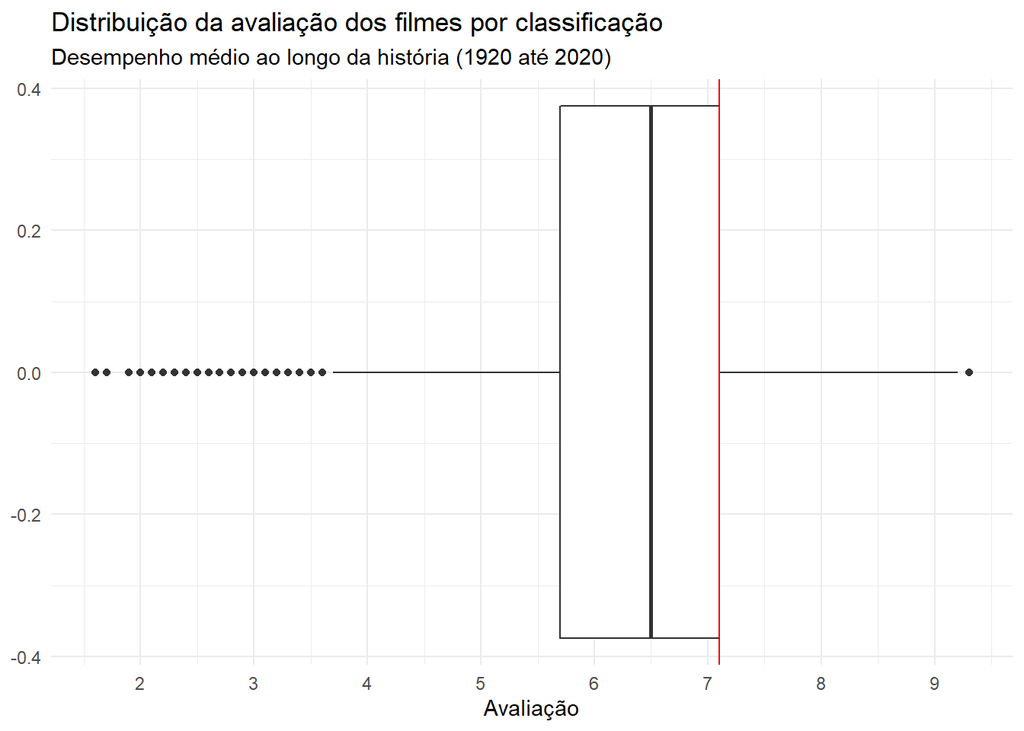

Consideraremos um filme como sucesso de crítica especializada sempre que estiver dentro do terceiro quartil. Isso, pois, somente um grupo especial de filmes conseguiu atingir desempenho neste índice. Logo, a nossa **nota limite do sucesso é 7**. E observar a evolução das notas ao longo dos anos deixa claro que realizar uma produção que esteja entre a “faixa de sucesso” é um grande desafio.

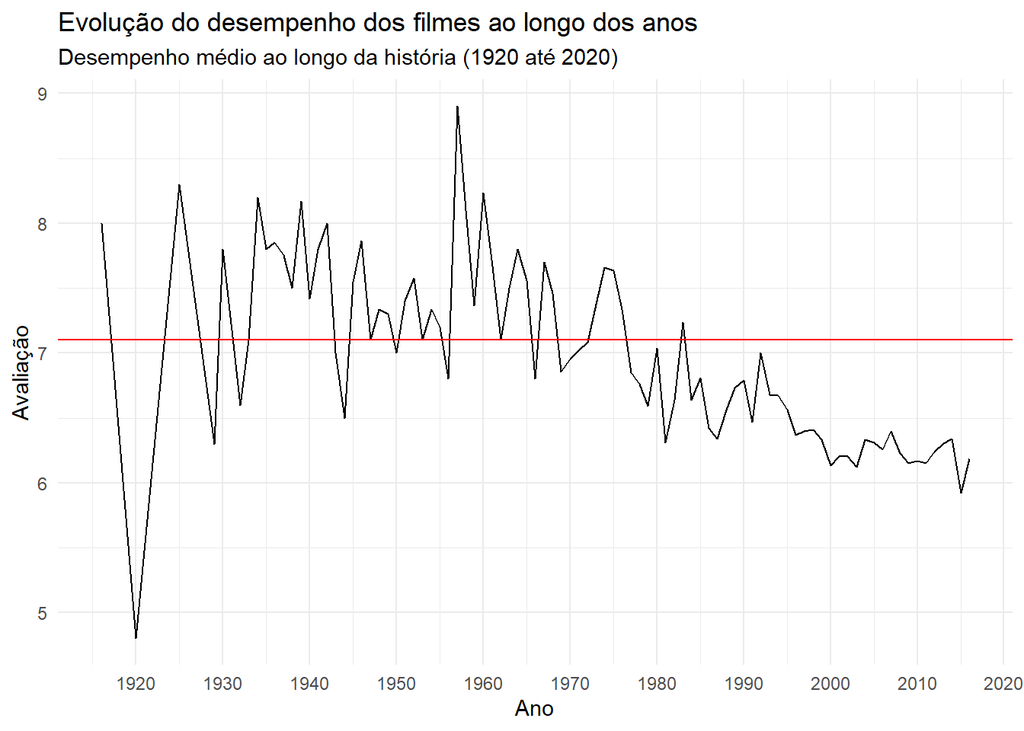

É possível notar que o desempenho médio dos filmes datados a partir da década de 90 adiante sempre esteve abaixo do recorte que estamos buscando.

**2 Existe relação entre investimento e sucesso?**

Como estamos buscando alcançar o desafio do filme ideal, é extremamente importante pensar no quanto precisaremos investir para chegar a esse patamar. Por isso, precisamos fazer a questão fundamental: é necessário investir muito dinheiro para ser notado?

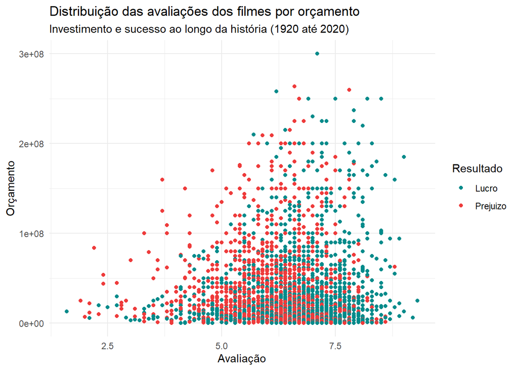

Nossa resposta é que (felizmente) não há uma relação direta entre investir e atingir o sucesso. Da mesma forma, também não há garantias de que o alto investimento garantirá lucro. Assim, conseguimos seguir em paz (e sem cortes) com nosso projeto.

Concluímos, assim, que buscaremos as características das películas avaliadas com nota maior que 7, utilizando o orçamento para apoiar a conquista do sucesso.

## **Qual gênero teve maior impacto no sucesso cinematográfico?**

Sendo assim, para entender o impacto que os gêneros dos filmes para alcançar o sucesso, buscaremos, inicialmente, compreender o grupo que conseguiu alcançar a maior margem de lucro ao longo dos anos dentro da nossa faixa de sucesso.

Para essa escolha, definimos uma quantidade de 5 filmes como “nota de corte” para estar na análise.

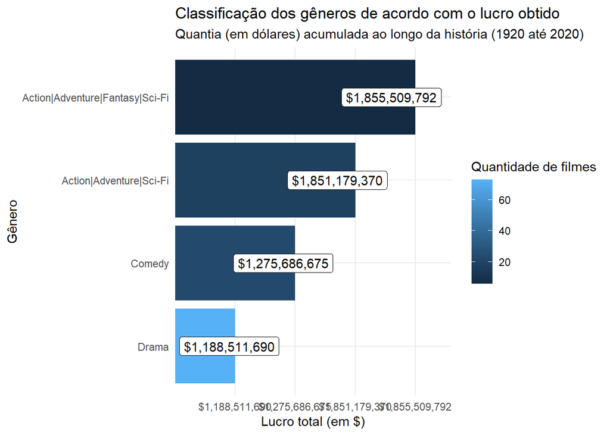

Assim, com a relação de gêneros que obtiveram maior lucro, é possível perceber que alguns temas aparecem fortemente na lista de “mais queridos” do público. Dessa forma, consideraremos a relação dessa lista como norte para a busca do gênero ideal para o sucesso.

Porém, ter o maior lucro não quer dizer que o filme seja o mais adequado para se investir, principalmente porque nosso interesse, aqui, não é torrar milhões e milhões sem responsabilidade.

Por isso, vamos incluir a análise do **retorno financeiro**. Esse dado representa **quantos dólares foi “lucrado” para cada dólar investido na produção do mesmo**. É importante frisar que ele leva em consideração o lucro pelo investimento realizado. Ou seja, os valores ficam dentro de uma escala e estão relacionados ao que valor além do planejado.

Com o grupo definido, precisamos observar o comportamento de cada gênero individualmente, separando-os dos seus grupos de relação com outros gêneros. Assim, conseguimos perceber o potencial de cada gênero de forma individual.

Tabela 1. Escolha do gênero para o filme ideal

| Gênero | Orçamento | Receita | Lucro | Retorno |
| --- | --- | --- | --- | --- |
| Comedy | $9,415,812,115 | $21,173,612,729 | $11,920,928,096 | 1.27 |
| Fantasy | $8,764,282,000 | $16,453,190,129 | $7,817,860,129 | 0.89 |
| Drama | $18,335,880,088 | $33,817,295,969 | $15,891,290,932 | 0.87 |
| Sci-Fi | $9,915,617,870 | $18,382,228,528 | $8,504,230,658 | 0.86 |
| Adventure | $18,170,808,087 | $32,348,618,062 | $14,339,768,062 | 0.79 |
| Action | $15,163,544,087 | $26,852,508,922 | $11,757,308,922 | 0.78 |

Definitivamente, **nossa produção deve trabalhar com os seguintes gêneros: Comédia, Fantasia e Drama**. Essa tríade garantirá, além do sucesso de crítica, o maior retorno possível.

## **Qual diretor nos ajudará a buscar nossa produção de sucesso?**

Para essa seleção, buscaremos os diretores que já trabalharam com nossos gêneros escolhidos (comédia, fantasia e drama). Agora, o foco não será mais o retorno financeiro, mas, sim, a equipe que conseguiu ser mais efetiva nas categorias que definimos como o filme ideal.

Neste caso, **efetividade se refere à proporção de filmes de sucesso que determinado(a) diretor(a) esteve envolvido(a)**.

Para iniciar esta investigação, cabe compreender qual é a relação de diretores(as) que mais se destacaram com filmes de sucesso. Dessa forma, a relação pode ser considerada o grupo de interesse para a nossa produção.Nesta escolha, definimos uma quantidade de 3 filmes como “nota de corte” para estar na análise.

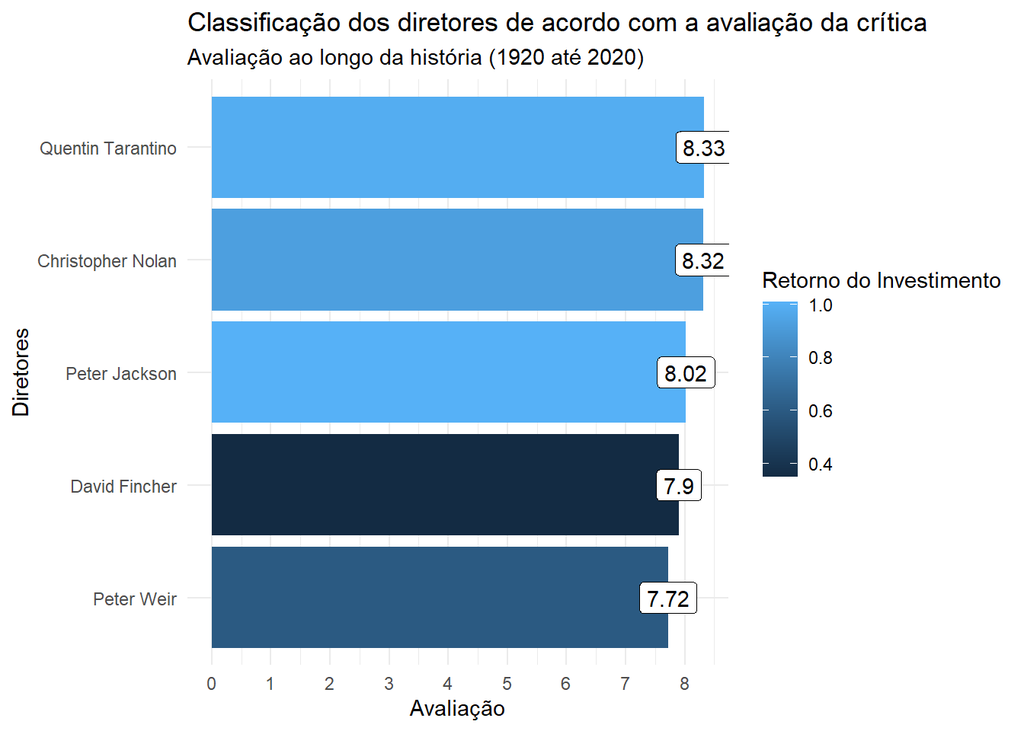

Assim, ao recortar o grupo de diretores(as) que tiveram melhor desempenho dentro de nossas definições de sucesso, conseguimos observar com mais atenção como foi o desempenho individual de cada um ao longo das produções. Alguns destaques apontam que determinados diretores não tiveram prejuízo ao longo dos anos. Ao mesmo tempo, outros dependem de um investimento alto para conseguir executar suas produções. Esta análise norteia a definição de quem produzirá nossa obra.

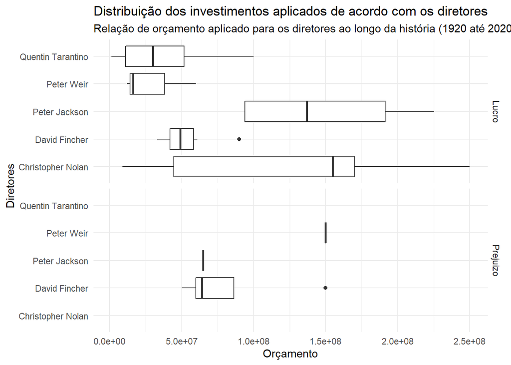

Após avaliar o investimento para cada um dos diretores selecionados. Acreditamos que a melhor opção para seguir na equipe é **a produção do diretor Quentin Tarantino**. A inclusão do campo **investimento médio por filme** é essencial para essa escolha, pois, além de ter um alto retorno e uma das melhores notas, o diretor também precisa de um investimento baixo para uma produção que dê lucro e obtenha sucesso (já que é bastante efetivo).

Tabela 2. Escolha dos(as) diretores(as) para o filme ideal

| Diretor | Desempenho | Produções | Efetividade | Investimento | Retorno |
| --- | --- | --- | --- | --- | --- |
| Peter Jackson | 8.02 | 5 | 80.0% | $131,600,000 | 1.01 |
| Quentin Tarantino | 8.33 | 6 | 100.0% | $43,033,333 | 0.99 |
| Christopher Nolan | 8.32 | 4 | 100.0% | $109,000,000 | 0.93 |
| Peter Weir | 7.72 | 4 | 100.0% | $59,600,000 | 0.60 |
| David Fincher | 7.90 | 9 | 89.0% | $66,666,667 | 0.35 |

## **Por fim, qual será o elenco a estrelar em nossa produção?**

Para a escolha dos(as) atores(atrizes), utilizaremos os mesmos critérios dos diretores(as). Ou seja buscaremos, dentro do nosso sonhado recorte de filme de sucesso, a equipe especializada, que tem um histórico de sucesso e pode garantir retorno financeiro. Aqui, voltaremos a falar sobre a **efetividade**.

Logo, vamos compreender a relação de quem mais se destacou com filmes de sucesso. Consequentemente, teremos os indivíduos que precisaremos observar com atenção. Assim como para diretores, aqui também definimos uma quantidade de 3 filmes como “nota de corte” para fazer parte da análise.

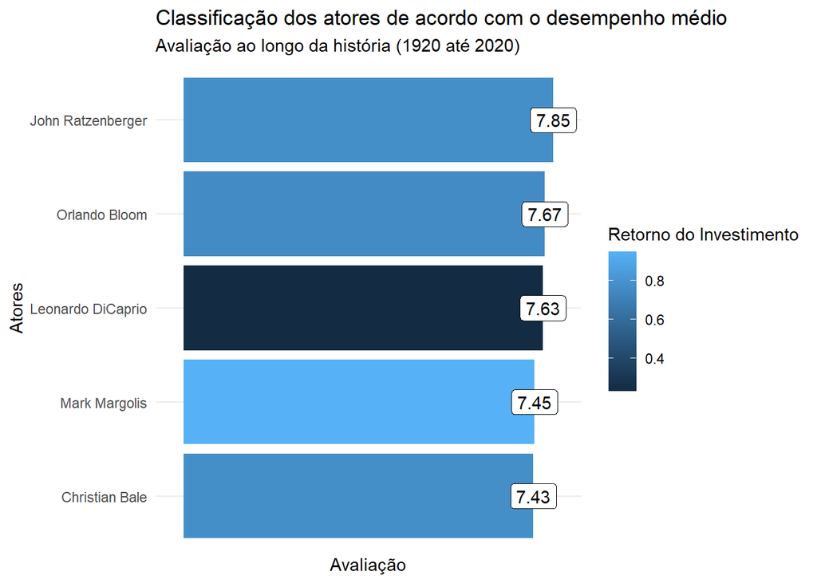

Do mesmo modo, temos nosso principal bloco de pessoas que vamos inserir na equipe, em busca de obter o maior sucesso possível.

Tabela 3. Escolha do elenco para o filme ideal

| Ator | Desempenho | Produções | Efetividade | Investimento | Retorno |
| --- | --- | --- | --- | --- | --- |
| John Ratzenberger | 7.85 | 6 | 100.0% | $157,500,000 | 0.78 |
| Orlando Bloom | 7.67 | 7 | 86.0% | $148,571,429 | 0.76 |
| Leonardo DiCaprio | 7.63 | 11 | 82.0% | $79,727,273 | 0.23 |
| Mark Margolis | 7.45 | 6 | 83.0% | $13,750,000 | 0.95 |
| Christian Bale | 7.43 | 15 | 80.0% | $42,933,333 | 0.78 |

Após avaliar o investimento para a construção do elenco, acreditamos que as melhores opções para integrar a equipe de Quentin Tarantino são:

1. um **ator efetivo** para ocupar o posto principal, no caso, **John Ratzenberger**, que ostenta **6 produções realizadas e 100% de produções de sucesso**;
2. um ator que garante um **alto retorno financeiro** no papel de coadjuvante. Por isso, **Mark Margolis** assumirá o posto. Ele garante um retorno de investimento de 0.95 dólar para cada dólar investido.
3. pro outro papel, apostaremos em um **ator experiente** e com um **bom retorno financeiro**. **Christian Bale** ocupará a última vaga. Ele trabalhou em **15 filmes** e tem uma **boa efetividade** com um **retorno de investimento razoável**.

## **Observações finais: pode haver mais alguma influência para o sucesso?**

Por fim, nos resta averiguar mais algumas variáveis que também podem impactar a nossa mega produção. Precisamos observar dois pontos: a duração dos filmes e a sua classificação etária.

Ao observarmos o primeiro item, categorizando em filmes longos e filmes curtos, nota-se que **a duração do filme parece não afetar diretamente na avaliação do mesmo**. Ou seja, essa categoria não influenciará diretamente nossa busca pelo sucesso de crítica.

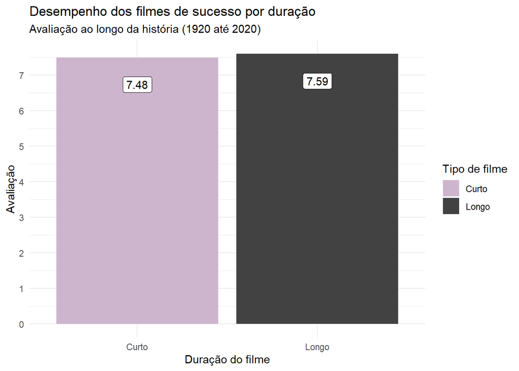

Do mesmo modo, **a classificação para o filme também não impacta no seu sucesso**. Entretanto, há de se relevar o leve favorecimento aos filmes que se enquadram na categoria **“Outros”**. Ou seja, talvez valha a pena deixar a produção dentro deste recorte.

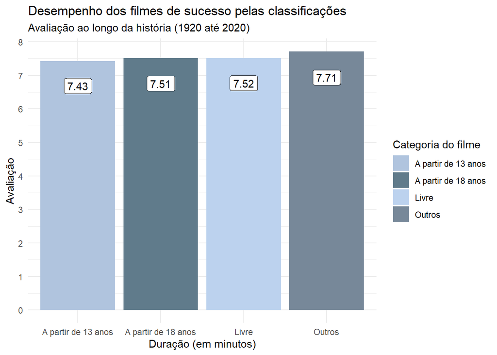

## **Conclusão: a definição da nossa produção**

Sendo assim, nosso cast fica da seguinte maneira:

Tabela 4. Roteiro para a produção de sucesso

| Gênero | Orçamento | Receita | Lucro | Retorno |
| --- | --- | --- | --- | --- |
| Comedy | $9,415,812,115 | $21,173,612,729 | $11,920,928,096 | 1.27 |
| Fantasy | $8,764,282,000 | $16,453,190,129 | $7,817,860,129 | 0.89 |
| Drama | $18,335,880,088 | $33,817,295,969 | $15,891,290,932 | 0.87 |

| Diretor | Desempenho | Produções | Efetividade | Investimento | Retorno |
| --- | --- | --- | --- | --- | --- |
| Quentin Tarantino | 8.33 | 6 | 100.0% | $43,033,333 | 0.99 |

| Ator | Desempenho | Produções | Efetividade | Investimento | Retorno |
| --- | --- | --- | --- | --- | --- |
| John Ratzenberger | 7.85 | 6 | 100.0% | $157,500,000 | 0.78 |
| Mark Margolis | 7.45 | 6 | 83.0% | $13,750,000 | 0.95 |
| Christian Bale | 7.43 | 15 | 80.0% | $42,933,333 | 0.78 |

Deste modo, obtemos a trilha de produção para que a Curso-R possa atingir o sucesso cinematográfico:

1. indicamos realizar um filme que envolva **Comédia**, **Fantasia** e **Drama**;
2. de preferência com **classificação etária definida como Outros**;
3. com direção de **Quentin Tarantino**;
4. e com o elenco principal com os atores **John Ratzenberger**, **Mark Margolis** e **Christian Bale**;

Com essas indicações, seria possível realizar um **filme que esteja no bloco principal da avaliação da crítica especializada** (com nota acima de 7), sendo uma **produção com um investimento de cerca de 250 milhões de dólares**, com uma **margem de retorno alta** (cerca de 0.99 de lucro para o seu valor investido) e **garantia de efetividade**.